# Armour change analysis

Thomas Guillerme

2017-11-27

# Pipeline for looking at (dis)appearance of armour per clade

```r
#install_github("TGuillerme/dispRity", ref = "release")
library(dispRity)
#install_github("TGuillerme/Inapp")
library(Inapp)
source("../Functions/clade.change_fun.R")
source("../Functions/timespines_fun.R")
set.seed(123)
```

The idea here is to: * Detect changes in armour in clades (loss or gain) * Measure the body mass + the age and environment of the members of clades changing

We can then check whether there is an increase/decrease in body mass related to gain/loss in armour through time. If there is a *danger zone*, we would expect an increase/decrease but not no changes.

> Note that there might be a caveat were we should correct for the overall trend in body mass variation for each clade. I.e. maybe the detected change in body mass when armour switch on/off is just part of the clade trend.

The data needed is thus: * A phylogeny (chronogram) * Body mass, and environment data * Armour information

## Data wrangling

```r
## Loading the body mass data
body_size <- read.csv("../Data/LaurenData/BodySizes/body_sizes.csv", stringsAsFactors = FALSE)

## Body size numeric conversion
body_size[,6] <- as.numeric(as.character(body_size[,6]))
## Getting species names
sp_names <- paste(body_size[,3], body_size[,4], sep = "_")

## Getting doubles
no_doubles <- unique(match(unique(sp_names), sp_names))

## Adding unique species names as rownames
body_size <- body_size[no_doubles, ]
rownames(body_size) <- unique(sp_names)

## Adding the group name for species with no subgroup name
body_size[,2] <- ifelse(is.na(body_size[,2]), body_size[,1], body_size[,2])
```

For now I’ll just generate some random armour data with no phylogenetic signal. We’ll eventually want to collect them for all these taxa.

Just for the purpose of illustration, we can create two scenarios of random armour:

- One completely random with a frequency of 0.85 of no armour beasties and 0.15 of armoured ones
- One “Danger-zone” simulation one with a frequency of 0.85/0.15 for armourless/armourness in taxa with body size above/below the median +/- two standard deviation and 0.15/0.85 of armourless/armourness for taxa with body size within the median +/- two standard deviation (basically setting the danger zone in the middle of the logged distribution).

```r
## Random armour data (1 = armour) with low-ish frequency (0.15)
armour_random <- sample(c(0,1), nrow(body_size), replace = TRUE, prob = c(0.85, 0.15))

## Danger zone simulation
median_dz <- exp(median(log(body_size[,6]), na.rm = TRUE))
sd_dz <- exp(sd(log(body_size[,6]), na.rm = TRUE))

## Selecting taxa in the simulated danger zone (roughly 10% of the taxa)
taxa_dz <- which(body_size[,6] >= (median_dz - 2*sd_dz) & body_size[,6] <= (median_dz + 2*sd_dz))
taxa_non_dz <- 1:nrow(body_size)[-taxa_dz]
dz_armour <- sample(c(0,1), length(taxa_dz), replace = TRUE, prob = c(0.15, 0.85))
non_dz_armour <- sample(c(0,1), length(taxa_non_dz), replace = TRUE, prob = c(0.85, 0.15))
## Attributing the armorness to the right taxa in a vector
armour_bias <- rep(0, nrow(body_size))
armour_bias[taxa_dz] <- dz_armour
armour_bias[taxa_non_dz] <- non_dz_armour

## Combining the data
body_size <- cbind(body_size, armour_random, armour_bias)
colnames(body_size)[c(ncol(body_size)-1, ncol(body_size))] <- c("Random", "Biased")
head(body_size)
```

```
##                                  Group       Subgroup       Genus
## Dialipina_markae        Actinopterygii Actinopterygii   Dialipina
## Ligulalepis_toombsi     Actinopterygii Actinopterygii Ligulalepis
## Dialipina_salgueroensis Actinopterygii Actinopterygii   Dialipina
## Cheirolepis_tralli      Actinopterygii Actinopterygii Cheirolepis
## Moythomasia_striatus    Actinopterygii Actinopterygii Moythomasia
## Donnrosenia_schaefferi  Actinopterygii Actinopterygii Donnrosenia
##                               Species         Stage.bin Body.size..cm.
## Dialipina_markae               markae Lochkovian-Emsian            6.3
## Ligulalepis_toombsi           toombsi            Emsian            7.3
## Dialipina_salgueroensis salgueroensis            Emsian           12.0
## Cheirolepis_tralli             tralli Eifelian-Givetian           25.0
## Moythomasia_striatus         striatus Eifelian-Frasnian           15.0
## Donnrosenia_schaefferi     schaefferi          Givetian           21.0
##                                    Citation Random Biased
## Dialipina_markae        Basden & Young 2001      0      0
## Ligulalepis_toombsi     Basden & Young 2001      0      1
## Dialipina_salgueroensis Basden & Young 2001      0      0
## Cheirolepis_tralli         Frickhinger 1991      1      0
## Moythomasia_striatus             Gross 1953      1      0
## Donnrosenia_schaefferi     Long et al. 2008      0      0
```

Now we need to collect the body sizes of the taxa that differentiate in terms of presence/absence of armourness compared to their clade. In other words “what is the body size of the taxon acquiring/losing armour within a clade”. Again, the idea being that when these taxa always acquire armour past a certain body size, they are entering the “danger zone” and when they are loosing it past another body size, they are exiting it.

I came up with three options for selecting the taxa with in armourness (regardless of gain/loss):

### Option 1: taxonomy

This is the simplest option: we don’t need any tree just taxonomic group names. Within each taxonomic group (genus, familly, order, class, etc…), we can get the majority armourness as the group’s state (i.e. the group can be armoured or not from the start) and see what is the body mass of the taxa that deviate from it.

The pros:

1. It doesn’t require any phylogeny so super fast/east to process

The cons:

1. Which taxonomic groups to use? Are they equivalent between clades?
2. The armourness majority trick doesn’t take into account phylogeny!

```r
## Getting the taxonomic groups
group_names <- unique(body_size[,1]) # 7 groups
subgroup_names <- unique(body_size[,2]) # 34 sub-groups
genera_names <- unique(body_size[,3]) # 727 genera

## Getting the changes per groups
group_changes_random <- sapply(group_names, taxonomy.change, group.level = 1, data.out = 6,
                               state = body_size$Random, data = body_size, simplify = FALSE)
group_changes_biased <- sapply(group_names, taxonomy.change, group.level = 1, data.out = 6,
                               state = body_size$Biased, data = body_size, simplify = FALSE)
subgroup_changes_random <- sapply(subgroup_names, taxonomy.change, group.level = 2, data.out = 6,
                                  state = body_size$Random, data = body_size, simplify = FALSE)
subgroup_changes_biased <- sapply(subgroup_names, taxonomy.change, group.level = 2, data.out = 6,
                                  state = body_size$Biased, data = body_size, simplify = FALSE)
genera_changes_random <- sapply(genera_names, taxonomy.change, group.level = 3, data.out = 6,
                                state = body_size$Random, data = body_size, simplify = FALSE)
genera_changes_biased <- sapply(genera_names, taxonomy.change, group.level = 3, data.out = 6,
                                state = body_size$Biased, data = body_size, simplify = FALSE)

## Extracting the body sizes of the changed taxa per groups
group_bs_change_random <- lapply(extract.change(group_changes_random, what = "changed.val"), log)
group_bs_change_biased <- lapply(extract.change(group_changes_biased, what = "changed.val"), log)
group_bs_normal <- lapply(extract.change(group_changes_random, what = "group.val"), log)
subgroup_bs_change_random <- lapply(extract.change(subgroup_changes_random, what = "changed.val"), log)
subgroup_bs_change_biased <- lapply(extract.change(subgroup_changes_biased, what = "changed.val"), log)
subgroup_bs_normal <- lapply(extract.change(subgroup_changes_random, what = "group.val"), log)
genera_bs_change_random <- lapply(extract.change(genera_changes_random, what = "changed.val"), log)
genera_bs_change_biased <- lapply(extract.change(genera_changes_biased, what = "changed.val"), log)
genera_bs_normal_r <- lapply(extract.change(genera_changes_random, what = "group.val"), log)
genera_bs_normal_b <- lapply(extract.change(genera_changes_biased, what = "group.val"), log)

## get the maximum of each group
group_max <- lapply(group_bs_normal, max, na.rm = TRUE)
subgroup_max <- lapply(subgroup_bs_normal, max, na.rm = TRUE)
genera_max_r <- lapply(genera_bs_normal_r, max, na.rm = TRUE)
genera_max_b <- lapply(genera_bs_normal_b, max, na.rm = TRUE)

## Normalising the body sizes relative to their group maximum
scale.fun <- function(X, Y) scale(X, center = FALSE, scale = Y)
gro_bs_norm_scal <- mapply(scale.fun, group_bs_normal, group_max, SIMPLIFY = FALSE)
gro_bs_chan_rand_scal <- mapply(scale.fun, group_bs_change_random, group_max, SIMPLIFY = FALSE)
gro_bs_chan_bias_scal <- mapply(scale.fun, group_bs_change_biased, group_max, SIMPLIFY = FALSE)
sub_bs_norm_scal <- mapply(scale.fun, subgroup_bs_normal, subgroup_max, SIMPLIFY = FALSE)
sub_bs_chan_rand_scal <- mapply(scale.fun, subgroup_bs_change_random, subgroup_max, SIMPLIFY = FALSE)
sub_bs_chan_bias_scal <- mapply(scale.fun, subgroup_bs_change_biased, subgroup_max, SIMPLIFY = FALSE)
gen_bs_norm_scal <- mapply(scale.fun, genera_bs_normal_b, genera_max_b, SIMPLIFY = FALSE)
gen_bs_chan_rand_scal <- mapply(scale.fun, genera_bs_change_random, genera_max_r, SIMPLIFY = FALSE)
gen_bs_chan_bias_scal <- mapply(scale.fun, genera_bs_change_biased, genera_max_b, SIMPLIFY = FALSE)
```

We can now visualise where do the group changes occur relative to their group size

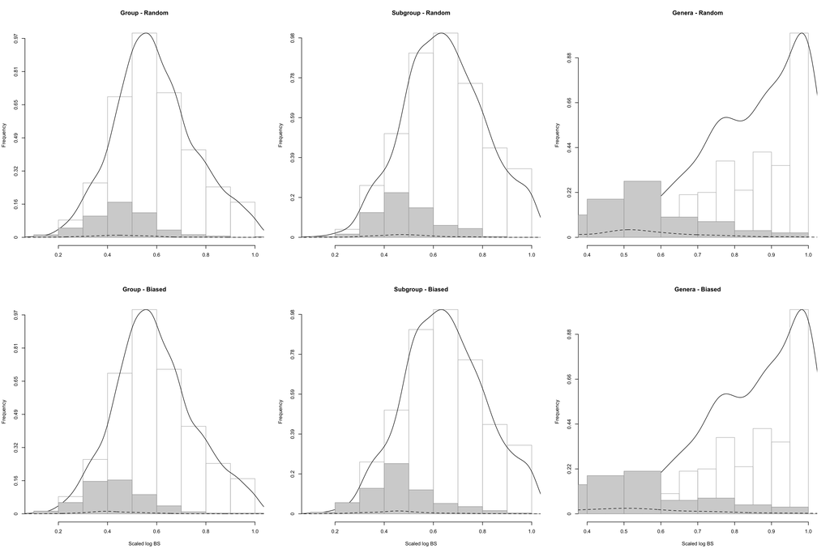

```r
## Graphical parameters
op <- par(mfrow = c(2,3))

## Plotting the pooled data for every group
plot.change(gro_bs_norm_scal, gro_bs_chan_rand_scal, main = "Group - Random", xlab = "")
## ... subgroup ...
plot.change(sub_bs_norm_scal, sub_bs_chan_rand_scal, main = "Subgroup - Random", xlab = "")
## ... and genera.
plot.change(gen_bs_norm_scal, gen_bs_chan_rand_scal, main = "Genera - Random", xlab = "")
## And the biased results
plot.change(gro_bs_norm_scal, gro_bs_chan_bias_scal, main = "Group - Biased",
            xlab = "Scaled log BS")
plot.change(sub_bs_norm_scal, sub_bs_chan_bias_scal, main = "Subgroup - Biased",
            xlab = "Scaled log BS")
plot.change(gen_bs_norm_scal, gen_bs_chan_bias_scal, main = "Genera - Biased",
            xlab = "Scaled log BS")
```

```r
par(op)
```

### Option 2: topology

This is an update on the Option 1 to correct for `cons 1.` by using topology to define a clade. Basically, we can apply a down pass procedure for every single tip and use a Fitch algorithm to check which node has a change or not (i.e. change from/to armourness) and select the body mass of the taxa changing or the average body mass of the clade changing (if the change occurs between two nodes).

The pros:

1. It doesn’t require clade definition
2. Using the Fitch algorithm, it’s easy to see where the changes occur

The cons:

1. It requires a phylogeny (though the phylogeny can be super crude, doesn’t need branch length and can contain big polytomies)
2. It still uses a trick to estimate what was the body mass of the taxa when the change occurs between two clades

```r
## Loading a tree
tree_placoderms <- read.nexus("../Data/Trees/Placoderms-King2017.tree")

## Matching the data
cleaned_data <- clean.data(body_size, tree_placoderms)
body_size_data <- cleaned_data$data
placoderms_tree <- cleaned_data$tree

## Removing tips with NAs from the tree
placoderms_tree <- drop.tip(placoderms_tree,
                       tip = rownames(body_size_data)[which(is.na(body_size_data[,6]))])

## Removing NAs from the data set
body_size_data <- body_size_data[-which(is.na(body_size_data[, 6])), ]

## Getting the characters
character_rand <- paste((body_size_data$Random[match(sort(rownames(body_size_data)),
                        (rownames(body_size_data)))]), collapse = "")
character_bias <- paste((body_size_data$Biased[match(sort(rownames(body_size_data)),
                        (rownames(body_size_data)))]), collapse = "")

## Traversal of the tree to detect changes.
traversal_rand <- apply.reconstruction(placoderms_tree, character_rand, passes = 1,
                                       method = "Fitch", match.tip.char = TRUE)
traversal_bias <- apply.reconstruction(placoderms_tree, character_bias, passes = 1,
                                       method = "Fitch", match.tip.char = TRUE)

## Get the subtrees with a state change
subtrees_rand <- sapply(traversal_rand$changes,
                        function(X, tree) return(extract.clade(tree, node = X)),
                        tree = placoderms_tree, simplify = FALSE)
subtrees_bias <- sapply(traversal_bias$changes,
                        function(X, tree) return(extract.clade(tree, node = X)),
                        tree = placoderms_tree, simplify = FALSE)

## Get the changes per clades
changes_rand <- lapply(subtrees_rand, topology.change, data = body_size_data,
                       state = body_size_data$Random, data.out = 6)
changes_bias <- lapply(subtrees_bias, topology.change, data = body_size_data,
                       state = body_size_data$Biased, data.out = 6)

## Extract the changes values
rand_norm <- lapply(extract.change(changes_rand, what = "group.val"), log)
rand_chan <- lapply(extract.change(changes_rand, what = "changed.val"), log)
bias_norm <- lapply(extract.change(changes_bias, what = "group.val"), log)
bias_chan <- lapply(extract.change(changes_bias, what = "changed.val"), log)

## get the maximum of each group
rand_max <- lapply(rand_norm, max, na.rm = TRUE)
bias_max <- lapply(bias_norm, max, na.rm = TRUE)

## Normalising the body sizes relative to their group maximum
rand_norm_scal <- mapply(scale.fun, rand_norm, rand_max, SIMPLIFY = FALSE)
rand_chan_scal <- mapply(scale.fun, rand_chan, rand_max, SIMPLIFY = FALSE)
bias_norm_scal <- mapply(scale.fun, bias_norm, bias_max, SIMPLIFY = FALSE)
bias_chan_scal <- mapply(scale.fun, bias_chan, bias_max, SIMPLIFY = FALSE)
```

We can now visualise where do the group changes occur relative to their group size

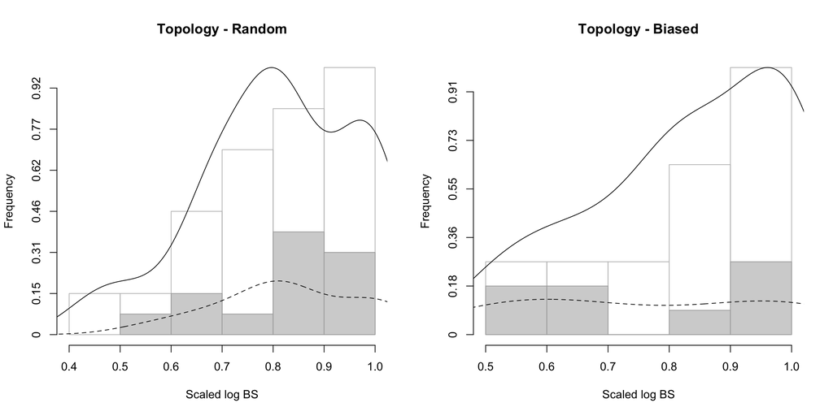

```r
## Graphical parameters
op <- par(mfrow = c(1,2))
## Plotting the pooled data for every group
plot.change(rand_norm_scal, rand_chan_scal, main = "Topology - Random", xlab = "Scaled log BS")
plot.change(bias_norm_scal, bias_chan_scal, main = "Topology - Biased", xlab = "Scaled log BS")
```

```r
par(op)
```

### Option 3: branch length

This one then tries to correct `cons 1.` from option 1 and `cons 2.` from option 2 by using both the topology and the branch length. The idea is to do an ancestral states reconstruction of the body size to have body size estimates at each nodes. We can then apply the same method as for option 2 but get the nodal estimated body size value when a change occurs rather than just the data for the taxa/clade where the change occurs.

The pros:

1. It doesn’t require clade definition
2. Using the Fitch algorithm, it’s easy to see where the changes occur
3. The body size at time of change is (more) correctly estimated statistically (i.e. including phylogenetic correction)

The cons:

1. It requires a correctly dated phylogeny.
2. It takes longer to compute ancestral body sizes
3. It’s still unclear which body size to consider at the time of the change (though that can be fixed by using ACCTRAN/DELTRAN or more complex rules: i.e. the armour (dis)appear at the node or at the tip - or somewhere in between).

```r
## Performing the ancestral states reconstruction
ace_body_size <- ace(body_size_data[match(placoderms_tree$tip.label, rownames(body_size_data)),6],
                     placoderms_tree, method = "pic")

## Extract the changes for each group
ace_change_rand <- log(ace_body_size$ace[traversal_rand$changes-Ntip(placoderms_tree)])
ace_change_bias <- log(ace_body_size$ace[traversal_bias$changes-Ntip(placoderms_tree)])

## Scale these values using the maximums from option 2
ace_change_rand_scal <- mapply(scale.fun, as.list(ace_change_rand), rand_max, SIMPLIFY = FALSE)
ace_change_bias_scal <- mapply(scale.fun, as.list(ace_change_bias), bias_max, SIMPLIFY = FALSE)
```

> Note that the method for the reconstructions is important here! I just go with the simple PIC method for convenience

Similarly we can now plot the differences:

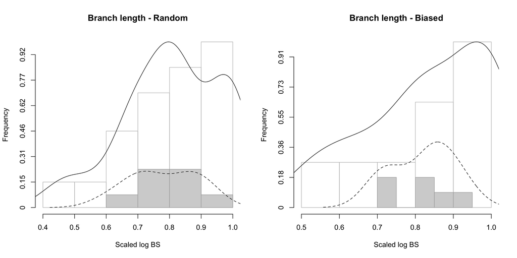

```r
## Graphical parameters
op <- par(mfrow = c(1,2))
## Plotting the pooled data for every group
plot.change(rand_norm_scal, ace_change_rand_scal, main = "Branch length - Random",
            xlab = "Scaled log BS")
plot.change(bias_norm_scal, ace_change_bias_scal, main = "Branch length - Biased",
            xlab = "Scaled log BS")
```

```r
par(op)
```